# Семинар 5. Множественная регрессия

Июнь, 14, 2018

# 1 Регрессия при гомоскедастичных ошибках

```r
library(tidyverse) # обработка данных, графики...
library(skimr) # описательные статистики
library(rio) # импорт фантастического количества форматов данных
library(broom) # метла превращает результаты оценивания моделей в таблички
library(GGally) # больше готовых графиков
library(sjPlot) # ещё больше графиков
library(lmtest) # диагностика линейных моделей
library(Ecdat) # много-много разных наборов данных
library(sjstats) # удобные мелкие функции для работы с моделями
library(sandwich) # оценка Var для гетероскедастичности
library(AER) # работа с инструментальными переменными
```

Возьмём набор данных об изменении пульса студентов до и после упражнений. Его описание доступно по [ссылке](http://www.statsci.org/data/oz/ms212.html).

Загрузим данные и посмотрим на описательные статистики.

Установите в качестве текущей папки ту папку, где лежит данный `.Rmd`-файл: `Session` — `Set working directory` — `To source file location`.

Правильно укажите путь к данным относительно `.Rmd`-файла:

```r
pulse <- import('data/pulse.txt')
skim(pulse)
```

```
## Skim summary statistics
##  n obs: 110
##  n variables: 11
##
## Variable type: integer
##  variable missing complete   n   mean    sd p0    p25   p50 p75 p100
##       Age       0      110 110  20.56  3.92 18  19     20    21   45
##   Alcohol       0      110 110   1.38  0.49  1   1      1     2    2
##  Exercise       0      110 110   2.21  0.65  1   2      2     3    3
##    Gender       0      110 110   1.46  0.5   1   1      1     2    2
##    Height       0      110 110 171.58 16.08 68 165.25 172.5 180  195
##    Pulse1       1      109 110  75.69 13.3  47  68     76    82  145
##    Pulse2       1      109 110  96.8  31.57 56  72     84   125  176
##       Ran       0      110 110   1.58  0.5   1   1      2     2    2
##    Smokes       0      110 110   1.9   0.3   1   2      2     2    2
##      Year       0      110 110  95.63  1.75 93  95     96    97   98
##      hist
##  ▇▁▁▁▁▁▁▁
##  ▇▁▁▁▁▁▁▅
##  ▂▁▁▇▁▁▁▅
##  ▇▁▁▁▁▁▁▇
##  ▁▁▁▁▁▂▇▅
##  ▁▇▇▃▁▁▁▁
##  ▅▇▃▁▃▂▂▁
##  ▆▁▁▁▁▁▁▇
##  ▁▁▁▁▁▁▁▇
##  ▇▁▁▇▆▁▇▆
##
## Variable type: numeric
##  variable missing complete   n  mean    sd p0   p25 p50 p75 p100     hist
##    Weight       0      110 110 66.33 15.16 27 56.25  63  75  110 ▁▁▇▇▅▃▁▁
```

- Сколько в данных наблюдений? Сколько переменных?
- Какие переменные на самом деле являются факторными?

Вернём факторным переменным положенный статус!

```r
pulse_fct <- pulse %>%
  mutate_at(vars(-Weight, -Height, -Age, -Pulse1, -Pulse2), factor)
```

И теперь можно приступать к регрессиям. Начнём с парной и построим регрессию пульса после упражнений `Pulse2` на константу и пульс до упражнений `Pulse1`. Для этого воспользуемся командой `lm()` и передадим ей данные и формулу.

```r
model_r <- lm(data = pulse_fct, Pulse2 ~ Pulse1)
```

С помощью команды `summary()` посмотрим на описание модели.

```r
summary(model_r)
```

```
##
## Call:
## lm(formula = Pulse2 ~ Pulse1, data = pulse_fct)
##
## Residuals:
##    Min     1Q Median     3Q    Max
## -29.09 -23.07 -17.92  28.08  72.65
##
## Coefficients:
##             Estimate Std. Error t value Pr(>|t|)
## (Intercept)  31.8476    16.4415   1.937 0.055379 .
## Pulse1        0.8581     0.2140   4.010 0.000113 ***
## ---
## Signif. codes:  0 '***' 0.001 '**' 0.01 '*' 0.05 '.' 0.1 ' ' 1
##
## Residual standard error: 29.57 on 107 degrees of freedom
##   (1 observation deleted due to missingness)
## Multiple R-squared:  0.1307, Adjusted R-squared:  0.1225
## F-statistic: 16.08 on 1 and 107 DF,  p-value: 0.0001125
```

- На сколько в среднем отличается пульс после упражнений у двух студентов, если пульс до упражнений у них отличается на единицу?
- Какие коэффициенты значимы?
- Какая доля разброса пульса после упражнений объясняется пульсом до упражнений?
- Упражнение 1.

Упражнения будем выполнять на встроенном наборе данных `Housing`. Посмотрите описание переменных в справке :) Затем «бросьте взгляд» на данные, есть ли в них факторные переменные, которые объявлены иначе?

```r
house <- Housing
glimpse(house)
```

```
## Observations: 546
## Variables: 12
## $ price    <dbl> 42000, 38500, 49500, 60500, 61000, 66000, 66000, 6900...
## $ lotsize  <dbl> 5850, 4000, 3060, 6650, 6360, 4160, 3880, 4160, 4800,...
## $ bedrooms <dbl> 3, 2, 3, 3, 2, 3, 3, 3, 3, 3, 3, 2, 3, 3, 2, 2, 3, 4,...
## $ bathrms  <dbl> 1, 1, 1, 1, 1, 1, 2, 1, 1, 2, 2, 1, 1, 1, 1, 1, 1, 1,...
## $ stories  <dbl> 2, 1, 1, 2, 1, 1, 2, 3, 1, 4, 1, 1, 2, 1, 1, 1, 2, 3,...
## $ driveway <fct> yes, yes, yes, yes, yes, yes, yes, yes, yes, yes, yes...
## $ recroom  <fct> no, no, no, yes, no, yes, no, no, yes, yes, no, no, n...
## $ fullbase <fct> yes, no, no, no, no, yes, yes, no, yes, no, yes, no, ...
## $ gashw    <fct> no, no, no, no, no, no, no, no, no, no, no, no, no, n...
## $ airco    <fct> no, no, no, no, no, yes, no, no, no, yes, yes, no, no...
## $ garagepl <dbl> 1, 0, 0, 0, 0, 0, 2, 0, 0, 1, 3, 0, 0, 0, 0, 0, 1, 0,...
## $ prefarea <fct> no, no, no, no, no, no, no, no, no, no, no, no, no, n...
```

Постройте парную регрессию цены дома `price` на константу и площадь дома `lotsize`.

```r
house_r <- lm(data = house, price ~ lotsize)
summary(house_r)
```

```
##
## Call:
## lm(formula = price ~ lotsize, data = house)
##
## Residuals:
##    Min     1Q Median     3Q    Max
## -69551 -14626  -2858   9752 106901
##
## Coefficients:
##              Estimate Std. Error t value Pr(>|t|)
## (Intercept) 3.414e+04  2.491e+03    13.7   <2e-16 ***
## lotsize     6.599e+00  4.458e-01    14.8   <2e-16 ***
## ---
## Signif. codes:  0 '***' 0.001 '**' 0.01 '*' 0.05 '.' 0.1 ' ' 1
##
## Residual standard error: 22570 on 544 degrees of freedom
## Multiple R-squared:  0.2871, Adjusted R-squared:  0.2858
## F-statistic: 219.1 on 1 and 544 DF,  p-value: < 2.2e-16
```

- Совпадает ли знак коэффициента при `lotsize` с ожидаемым?
- Можно ли считать коэффициента при `lotsize` значимым на уровне 1%?

Другой способ посмотреть на описание модели — воспользоваться функциями пакета `broom`. Оценки коэффциентов, стандартные ошибки, p-значения выводит команда `tidy()`:

```r
tidy(model_r)
```

```
##          term   estimate  std.error statistic      p.value
## 1 (Intercept) 31.8476001 16.4414717  1.937029 0.0553785865
## 2      Pulse1  0.8581347  0.2139792  4.010365 0.0001125123
```

А функция `glance()` покажет общие характеристики модели, для которых достаточно одной строчки, — коэффциент детерминации, значение лог-функции правдоподобия, AIC, BIC…

```r
glance(model_r)
```

```
##   r.squared adj.r.squared   sigma statistic      p.value df    logLik
## 1 0.1306681     0.1225435 29.5705  16.08303 0.0001125123  2 -522.8137
##        AIC      BIC deviance df.residual
## 1 1051.627 1059.701 93562.33         107
```

Если из общей таблицы описания модели нужна только информация о коэффициентах, то поможет команда `coeftest()` из пакета `lmtest()`.

```r
coeftest(model_r)
```

```
##
## t test of coefficients:
##
##             Estimate Std. Error t value  Pr(>|t|)
## (Intercept) 31.84760   16.44147  1.9370 0.0553786 .
## Pulse1       0.85813    0.21398  4.0104 0.0001125 ***
## ---
## Signif. codes:  0 '***' 0.001 '**' 0.01 '*' 0.05 '.' 0.1 ' ' 1
```

Нарисуем линию регрессии для модели, в которой зависимая переменная — это пульс после упражнений, а объясняющая — пульс до упражнений. Для этого к диаграмме рассеяния добавим дополнительный слой `geom_smooth()`. Внутри него за линейную регрессию отвечает `method = 'lm'`.

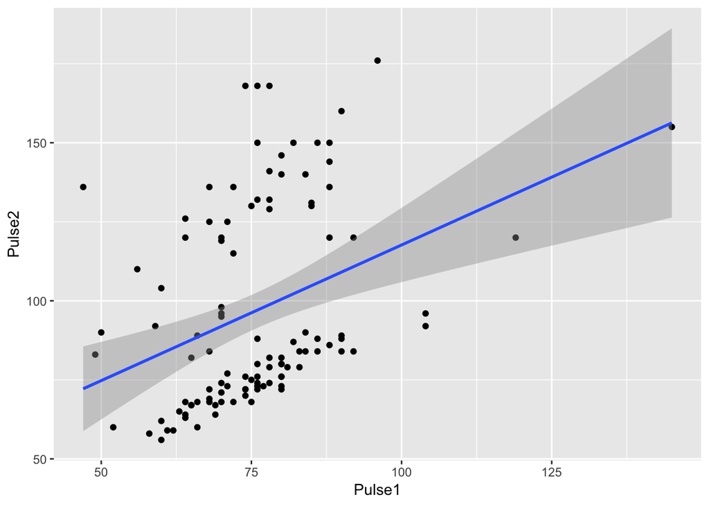

```r
ggplot(data = pulse_fct, aes(x = Pulse1, y = Pulse2)) +
  geom_point() +
  geom_smooth(method = 'lm')
```

- Упражнение 2.

Визуализируйте линию регрессии для модели `house_r`. В ней зависимой переменной была цена дома `price`, а объясняющей — площадь `lotsize`.

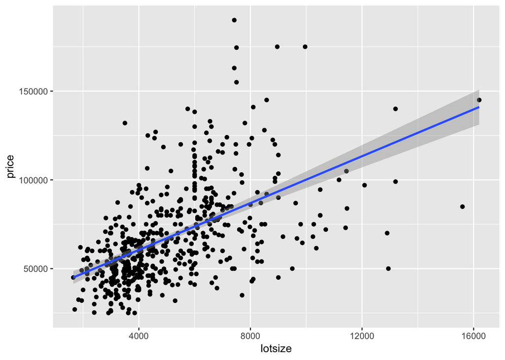

```r
ggplot(data = house, aes(x = lotsize, y = price)) +
   geom_point() +
   geom_smooth(method = 'lm')
```

```r
model_ur <- lm(data = pulse_fct, Pulse2 ~ Weight + Pulse1 + Ran + Smokes)
summary(model_ur)
```

```
##
## Call:
## lm(formula = Pulse2 ~ Weight + Pulse1 + Ran + Smokes, data = pulse_fct)
##
## Residuals:
##     Min      1Q  Median      3Q     Max
## -39.631  -3.717   0.170   4.360  42.354
##
## Coefficients:
##              Estimate Std. Error t value Pr(>|t|)
## (Intercept)  56.12572   12.14842   4.620 1.10e-05 ***
## Weight        0.02187    0.09113   0.240    0.811
## Pulse1        0.89417    0.10421   8.580 9.77e-14 ***
## Ran2        -52.20287    2.75215 -18.968  < 2e-16 ***
## Smokes2       1.90805    4.52173   0.422    0.674
## ---
## Signif. codes:  0 '***' 0.001 '**' 0.01 '*' 0.05 '.' 0.1 ' ' 1
##
## Residual standard error: 14.1 on 104 degrees of freedom
##   (1 observation deleted due to missingness)
## Multiple R-squared:  0.8078, Adjusted R-squared:  0.8004
## F-statistic: 109.3 on 4 and 104 DF,  p-value: < 2.2e-16
```

- Упражнение 3.

Оцените более сложную модель для набора данных о домах. Среди объясняющих переменных укажите площадь дома `lotsize`, количсевто спален `bedrooms` и бинарную переменную `prefarea`, которая равна 1 для домов, расположенных в хороших районах.

```r
house_ur <- lm(data = house, price ~ lotsize + bedrooms + prefarea)
summary(house_ur)
```

```
##
## Call:
## lm(formula = price ~ lotsize + bedrooms + prefarea, data = house)
##
## Residuals:
##    Min     1Q Median     3Q    Max
## -58243 -13182  -2681   9315  89082
##
## Coefficients:
##              Estimate Std. Error t value Pr(>|t|)
## (Intercept) 6.515e+03  3.982e+03   1.636    0.102
## lotsize     5.485e+00  4.225e-01  12.984  < 2e-16 ***
## bedrooms    1.024e+04  1.211e+03   8.457 2.57e-16 ***
## prefareayes 1.273e+04  2.142e+03   5.944 4.97e-09 ***
## ---
## Signif. codes:  0 '***' 0.001 '**' 0.01 '*' 0.05 '.' 0.1 ' ' 1
##
## Residual standard error: 20590 on 542 degrees of freedom
## Multiple R-squared:  0.4088, Adjusted R-squared:  0.4055
## F-statistic: 124.9 on 3 and 542 DF,  p-value: < 2.2e-16
```

Есть ли проблемы у модели? Диагностический график в студию!

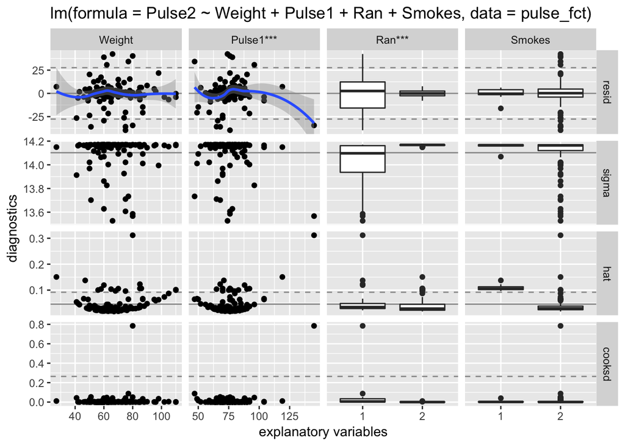

```r
ggnostic(model = model_ur)
```

На этом графике четыре линии! * Первая: зависимость величины остатка $\hat u_i = y_i - \hat y_i$ от каждого регрессора. * Вторая: зависимость величины $\hat \sigma_i$ от каждого регрессора.

Величина $\hat \sigma_i$ показывает, какой была бы оценка стандартного отклонения случайной составляющей, если бы $i$-ое наблюдение выкинули из модели.

Слишком маленькие значения $\hat \sigma_i$ говорят о том, что при выкидывании наблюдения резко падает оценка стандартного отклонения. Значит, наблюдение могло быть выбросом.

- Третья: зависимость величины $h_{ii}$ от каждого регрессора.

Величина $h_{ii}$ имеет две интерпретации. Во-первых, она показывает, насколько изменится прогноз $\hat y_i$ при увеличении фактического наблюдения $y_i$ на единицу. Во-вторых, эта величина показывает отношение дисперсии прогноза $\hat y_i$ к дисперсии случайной составляющей:
$$h_{ii} = \frac{Var(\hat y_i)}{Var(u_i)}$$

- Четвертая: зависимость расстояния Кука от каждого из регрессоров.

Расстояние Кука показывает, насколько сильно изменятся прогнозы по всему набору данных, при выкидывании $i$-го наблюдения,

$$D_i = \frac{\sum_{j=1}^n(\hat y_j - \hat y_j^{(-i)})^2}{k\hat\sigma^2},$$
где $k$ — число регрессоров, считая единичный столбец.

Подробнее про расстояние Кука можно прочитать в маленьких [заметках](http://bdemeshev.github.io/r_cycle/cycle_files/02_ols_oranges.html).

- Какие наблюдения являются потенциальными выбросами?

```r
coefci(model_ur)
```

```
##                   2.5 %      97.5 %
## (Intercept)  32.0349494  80.2164943
## Weight       -0.1588415   0.2025909
## Pulse1        0.6875121   1.1008223
## Ran2        -57.6604911 -46.7452493
## Smokes2      -7.0587150  10.8748163
```

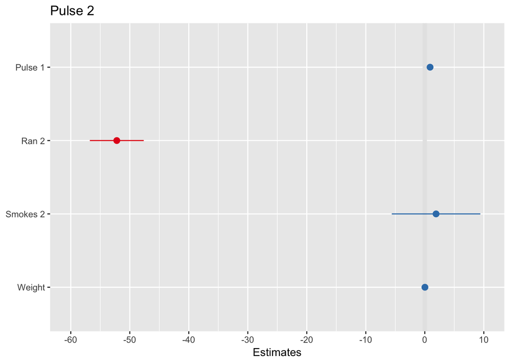

```r
plot_model(model_ur, ci.lvl = 0.9)
```

- Загляните в справку :) Какая опция функции `coefci` отвечает за уровень доверия?
- Упражнение 4.

Постройте 95%-ные доверительные интервалы для всех коэффициентов модели `house_ur` и визуализируйте их.

```r
coefci(house_ur)
```

```
##                    2.5 %       97.5 %
## (Intercept) -1307.098806 14336.341933
## lotsize         4.655317     6.315047
## bedrooms     7863.559266 12622.144408
## prefareayes  8524.476076 16938.849973
```

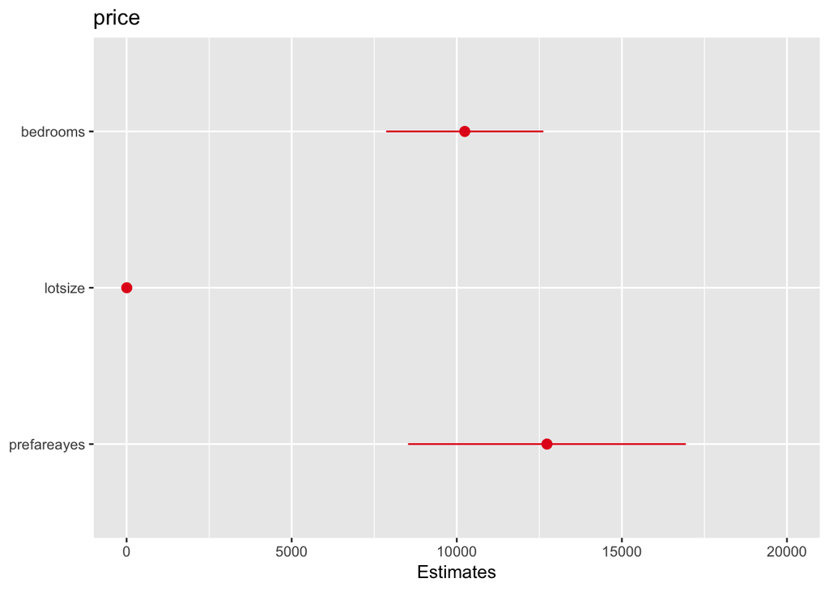

```r
plot_model(house_ur, ci.lvl = 0.95)
```

Если есть две вложенных модели, то есть одна является частным случаем другой, то можно провести тест Вальда, чтобы выбрать одну из них.

$H_0$: верна ограниченная (короткая) модель;

$H_a$: верная неограниченная (длинная) модель;

```r
waldtest(model_r, model_ur)
```

```
## Wald test
##
## Model 1: Pulse2 ~ Pulse1
## Model 2: Pulse2 ~ Weight + Pulse1 + Ran + Smokes
##   Res.Df Df      F    Pr(>F)
## 1    107
## 2    104  3 122.16 < 2.2e-16 ***
## ---
## Signif. codes:  0 '***' 0.001 '**' 0.01 '*' 0.05 '.' 0.1 ' ' 1
```

Сравниваем p-значение с уровнем значимости.

- Упражнение 5.

Проведите тест Вальда для моделей `house_r` и `huose_ur`.

```r
waldtest(house_r, house_ur)
```

```
## Wald test
##
## Model 1: price ~ lotsize
## Model 2: price ~ lotsize + bedrooms + prefarea
##   Res.Df Df      F    Pr(>F)
## 1    544
## 2    542  2 55.804 < 2.2e-16 ***
## ---
## Signif. codes:  0 '***' 0.001 '**' 0.01 '*' 0.05 '.' 0.1 ' ' 1
```

- Какую модель следует выбрать по результатам теста на 5%-ом уровне значимости?

# 2 О бедном t-тесте замолвите слово!

Иногда душа хочет проверки самых простых гипотез!

Если хочется построить доверительный интервал для математического ожидания пульса до упражнений, то достаточно построить регрессию на константу:

```r
model_mu <- lm(data = pulse_fct, Pulse1 ~ 1)
coefci(model_mu)
```

```
##                2.5 %   97.5 %
## (Intercept) 73.16341 78.21274
```

Если хочется построить доверительный интервал для разности математического ожидания пульса у курящих и некурящих, то можно построить регрессию на константу и дамми-переменную.

```r
model_diff <- lm(data = pulse_fct, Pulse1 ~ Smokes)
coefci(model_diff)
```

```
##                 2.5 %    97.5 %
## (Intercept)  69.56907 85.521838
## Smokes2     -10.47800  6.346272
```

- Упражнение 6.

Постройте доверительный интервал для математического ожидания цены и доверительный интервал для разности математических ожиданий цены дома в хорошем и обычном районе.

```r
house_mu <- lm(data = house, price ~ 1)
summary(house_mu)
```

```
##
## Call:
## lm(formula = price ~ 1, data = house)
##
## Residuals:
##    Min     1Q Median     3Q    Max
## -43122 -18997  -6122  13878 121878
##
## Coefficients:
##             Estimate Std. Error t value Pr(>|t|)
## (Intercept)    68122       1143   59.61   <2e-16 ***
## ---
## Signif. codes:  0 '***' 0.001 '**' 0.01 '*' 0.05 '.' 0.1 ' ' 1
##
## Residual standard error: 26700 on 545 degrees of freedom
```

```r
house_diff <- lm(data = house, price ~ prefarea)
summary(house_diff)
```

```
##
## Call:
## lm(formula = price ~ prefarea, data = house)
##
## Residuals:
##    Min     1Q Median     3Q    Max
## -52086 -17263  -4486  10664 111737
##
## Coefficients:
##             Estimate Std. Error t value Pr(>|t|)
## (Intercept)    63264       1234  51.248  < 2e-16 ***
## prefareayes    20723       2550   8.128 2.96e-15 ***
## ---
## Signif. codes:  0 '***' 0.001 '**' 0.01 '*' 0.05 '.' 0.1 ' ' 1
##
## Residual standard error: 25240 on 544 degrees of freedom
## Multiple R-squared:  0.1083, Adjusted R-squared:  0.1067
## F-statistic: 66.06 on 1 and 544 DF,  p-value: 2.959e-15
```

Дисперсионный анализ легким движением руки также заменяется на построение единственной регрессии.

Проверим, что две качественные переменные, `Smokes` и `Gender`, не оказывают влияния на частоту пульса.

```r
model_2anova <- lm(data = pulse_fct, Pulse1 ~ Smokes * Gender)
summary(model_2anova)
```

```
##
## Call:
## lm(formula = Pulse1 ~ Smokes * Gender, data = pulse_fct)
##
## Residuals:
##     Min      1Q  Median      3Q     Max
## -30.298  -8.375   0.196   6.196  71.196
##
## Coefficients:
##                 Estimate Std. Error t value Pr(>|t|)
## (Intercept)      76.3750     4.7203  16.180   <2e-16 ***
## Smokes2          -2.5711     5.0771  -0.506    0.614
## Gender2           4.2917     9.0387   0.475    0.636
## Smokes2:Gender2  -0.7977     9.4333  -0.085    0.933
## ---
## Signif. codes:  0 '***' 0.001 '**' 0.01 '*' 0.05 '.' 0.1 ' ' 1
##
## Residual standard error: 13.35 on 105 degrees of freedom
##   (1 observation deleted due to missingness)
## Multiple R-squared:  0.01995,    Adjusted R-squared:  -0.008052
## F-statistic: 0.7124 on 3 and 105 DF,  p-value: 0.5467
```

```r
anova_stats(model_2anova)
```

```
## # A tibble: 4 x 12
##   term     df  sumsq meansq statistic p.value  etasq partial.etasq omegasq
##   <chr> <dbl>  <dbl>  <dbl>     <dbl>   <dbl>  <dbl>         <dbl>   <dbl>
## 1 Smok…     1 4.22e1  42.2      0.237   0.628  0.002         0.002  -0.007
## 2 Gend…     1 3.38e2 338.       1.89    0.172  0.018         0.018   0.008
## 3 Smok…     1 1.27e0   1.27     0.007   0.933  0             0      -0.009
## 4 Resi…   105 1.87e4 178.      NA      NA     NA            NA      NA
## # ... with 3 more variables: partial.omegasq <dbl>, cohens.f <dbl>,
## #   power <dbl>
```

- Упражнение 7.

Проверьте, что наличие подъезда к дому `driveway` и расположение в хорошем районе `prefarea`, не влияют на цену дома.

```r
house_2anova <- lm(data = house, price ~ driveway * prefarea)
summary(house_2anova)
```

```
##
## Call:
## lm(formula = price ~ driveway * prefarea, data = house)
##
## Residuals:
##    Min     1Q Median     3Q    Max
## -41441 -16441  -4441  11163 108559
##
## Coefficients:
##                         Estimate Std. Error t value Pr(>|t|)
## (Intercept)                48732       2822  17.271  < 2e-16 ***
## drivewayyes                17709       3115   5.685 2.14e-08 ***
## prefareayes                -6782      17508  -0.387    0.699
## drivewayyes:prefareayes    24995      17692   1.413    0.158
## ---
## Signif. codes:  0 '***' 0.001 '**' 0.01 '*' 0.05 '.' 0.1 ' ' 1
##
## Residual standard error: 24440 on 542 degrees of freedom
## Multiple R-squared:  0.1672, Adjusted R-squared:  0.1626
## F-statistic: 36.27 on 3 and 542 DF,  p-value: < 2.2e-16
```

# 3 Регрессия при гетероскедастичных ошибках

Если не предполагать, что дисперсии ошибок $Var(u_i)$ одинаковы для всех наблюдений, то построенные нами доверительные интервалы и выполненная проверка гипотез — полный отстой :)

Повторяем табличку с тестами на значимость отдельных коэффициентов с учётом поправки на гетероскедастичность.

```r
coeftest(model_ur, vcov. = vcovHC)
```

```
##
## t test of coefficients:
##
##               Estimate Std. Error  t value  Pr(>|t|)
## (Intercept)  56.125722  21.191573   2.6485  0.009345 **
## Weight        0.021875   0.095912   0.2281  0.820039
## Pulse1        0.894167   0.217629   4.1087 7.954e-05 ***
## Ran2        -52.202870   3.252667 -16.0492 < 2.2e-16 ***
## Smokes2       1.908051   2.516461   0.7582  0.450029
## ---
## Signif. codes:  0 '***' 0.001 '**' 0.01 '*' 0.05 '.' 0.1 ' ' 1
```

Также легко получить доверительные интервалы:

```r
coefci(model_ur, vcov. = vcovHC)
```

```
##                   2.5 %      97.5 %
## (Intercept)  14.1020380  98.1494057
## Weight       -0.1683218   0.2120713
## Pulse1        0.4626001   1.3257342
## Ran2        -58.6530314 -45.7527089
## Smokes2      -3.0821863   6.8982876
```

Результаты в R чуть отличаются от результатов в stata. По-умолчанию, R использует корректировку HC3 для подсчёта стандартных ошибок коэффициентов, а stata — менее удачную, устаревшую HC1. Сравнение есть у [Achim Zeileis](https://cran.r-project.org/web/packages/sandwich/vignettes/sandwich.pdf). Если хочется воспроизвести именно корректировку HC1, то запросто :)

```r
coeftest(model_ur, vcov. = vcovHC(model_ur, type = "HC1"))
```

```
##
## t test of coefficients:
##
##               Estimate Std. Error  t value  Pr(>|t|)
## (Intercept)  56.125722  16.388352   3.4247 0.0008819 ***
## Weight        0.021875   0.084090   0.2601 0.7952746
## Pulse1        0.894167   0.165376   5.4069 4.111e-07 ***
## Ran2        -52.202870   3.121163 -16.7255 < 2.2e-16 ***
## Smokes2       1.908051   2.250136   0.8480 0.3984014
## ---
## Signif. codes:  0 '***' 0.001 '**' 0.01 '*' 0.05 '.' 0.1 ' ' 1
```

Сравним две вложенных модели с учётом поправки на гетероскедастичность:

```r
waldtest(model_r, model_ur, vcov = vcovHC)
```

```
## Wald test
##
## Model 1: Pulse2 ~ Pulse1
## Model 2: Pulse2 ~ Weight + Pulse1 + Ran + Smokes
##   Res.Df Df      F    Pr(>F)
## 1    107
## 2    104  3 91.751 < 2.2e-16 ***
## ---
## Signif. codes:  0 '***' 0.001 '**' 0.01 '*' 0.05 '.' 0.1 ' ' 1
```

- Упражнение 8.

Получите таблицу с тестами на значимость коэффициентов в модели `house_ur`, используя корректировку `HC3`. А затем сравните две модели `house_r` и `house_ur` с учётом поправки на гетероскедастичность.

```r
coeftest(house_ur, vcov. = vcovHC, type = 'HC3')
```

```
##
## t test of coefficients:
##
##               Estimate Std. Error t value  Pr(>|t|)
## (Intercept) 6.5146e+03 3.8045e+03  1.7123   0.08741 .
## lotsize     5.4852e+00 5.2896e-01 10.3697 < 2.2e-16 ***
## bedrooms    1.0243e+04 1.2472e+03  8.2128 1.593e-15 ***
## prefareayes 1.2732e+04 2.2766e+03  5.5924 3.555e-08 ***
## ---
## Signif. codes:  0 '***' 0.001 '**' 0.01 '*' 0.05 '.' 0.1 ' ' 1
```

```r
waldtest(house_r, house_ur, vcov =  vcovHC)
```

```
## Wald test
##
## Model 1: price ~ lotsize
## Model 2: price ~ lotsize + bedrooms + prefarea
##   Res.Df Df      F    Pr(>F)
## 1    544
## 2    542  2 52.281 < 2.2e-16 ***
## ---
## Signif. codes:  0 '***' 0.001 '**' 0.01 '*' 0.05 '.' 0.1 ' ' 1
```

# 4 Инструментальные переменные

Исследователи всегда мечтают обнаружить не просто статистическую связь, а причинно-следственную. Проще всего было бы обнаружить связь с помощью рандомизированного эксперимента: поделить случайно индивидов случайно на две группы, одну попросить стирать обычным порошком, а вторую — новым чудопорошком. Важно упаковать порошки совершенно одинаково и говорить одни и те же слова :)

Мы часто имеем с данными наблюдений. Рандомизированного эксперимента при этом не было. В редких случаях можно попытаться обнаружить причинно-следственную связь на данных наблюдений.

Рассмотрим набор данных по предложению труда женщин `Mroz` из пакета `Ecdat`.

```r
mroz <- Ecdat::Mroz
glimpse(mroz)
```

```
## Observations: 753
## Variables: 18
## $ work       <fct> no, no, no, no, no, no, no, no, no, no, no, no, no,...
## $ hoursw     <int> 1610, 1656, 1980, 456, 1568, 2032, 1440, 1020, 1458...
## $ child6     <int> 1, 0, 1, 0, 1, 0, 0, 0, 0, 0, 0, 0, 1, 0, 0, 0, 0, ...
## $ child618   <int> 0, 2, 3, 3, 2, 0, 2, 0, 2, 2, 1, 1, 2, 2, 1, 3, 2, ...
## $ agew       <int> 32, 30, 35, 34, 31, 54, 37, 54, 48, 39, 33, 42, 30,...
## $ educw      <int> 12, 12, 12, 12, 14, 12, 16, 12, 12, 12, 12, 11, 12,...
## $ hearnw     <dbl> 3.3540, 1.3889, 4.5455, 1.0965, 4.5918, 4.7421, 8.3...
## $ wagew      <dbl> 2.65, 2.65, 4.04, 3.25, 3.60, 4.70, 5.95, 9.98, 0.0...
## $ hoursh     <int> 2708, 2310, 3072, 1920, 2000, 1040, 2670, 4120, 199...
## $ ageh       <int> 34, 30, 40, 53, 32, 57, 37, 53, 52, 43, 34, 47, 33,...
## $ educh      <int> 12, 9, 12, 10, 12, 11, 12, 8, 4, 12, 12, 14, 16, 12...
## $ wageh      <dbl> 4.0288, 8.4416, 3.5807, 3.5417, 10.0000, 6.7106, 3....
## $ income     <int> 16310, 21800, 21040, 7300, 27300, 19495, 21152, 189...
## $ educwm     <int> 12, 7, 12, 7, 12, 14, 14, 3, 7, 7, 12, 14, 16, 10, ...
## $ educwf     <int> 7, 7, 7, 7, 14, 7, 7, 3, 7, 7, 3, 7, 16, 10, 7, 10,...
## $ unemprate  <dbl> 5.0, 11.0, 5.0, 5.0, 9.5, 7.5, 5.0, 5.0, 3.0, 5.0, ...
## $ city       <fct> no, yes, no, no, yes, yes, no, no, no, no, no, no, ...
## $ experience <int> 14, 5, 15, 6, 7, 33, 11, 35, 24, 21, 15, 14, 0, 14,...
```

Отберём работавших женщин.

```r
labor <- filter(mroz, wagew > 0)
```

Мы хотим оценить причинно-следственный эффект от дополнительного года обучения на заработную плату женщины.

На первый взгляд разумно попробовать обычный МНК:

```r
model_lm <- lm(data = labor, log(wagew) ~ educw + experience + I(experience^2))
summary(model_lm)
```

```
##
## Call:
## lm(formula = log(wagew) ~ educw + experience + I(experience^2),
##     data = labor)
##
## Residuals:
##      Min       1Q   Median       3Q      Max
## -1.22168 -0.22193  0.00529  0.24018  1.17754
##
## Coefficients:
##                   Estimate Std. Error t value Pr(>|t|)
## (Intercept)      0.0310084  0.1295490   0.239  0.81098
## educw            0.0834844  0.0090775   9.197  < 2e-16 ***
## experience       0.0238019  0.0087690   2.714  0.00699 **
## I(experience^2) -0.0003113  0.0002532  -1.229  0.21983
## ---
## Signif. codes:  0 '***' 0.001 '**' 0.01 '*' 0.05 '.' 0.1 ' ' 1
##
## Residual standard error: 0.3784 on 332 degrees of freedom
## Multiple R-squared:  0.2524, Adjusted R-squared:  0.2457
## F-statistic: 37.37 on 3 and 332 DF,  p-value: < 2.2e-16
```

Эта регрессия прекрасно оценивает силу статистической взаимосвязи и показывает, насколько различается зарплата двух женщин, у которых разное образование, и одинаковый опыт работы.

Эта регрессия вовсе не говорит, насколько увеличится зарплата данной женщины, если она надумает ещё год поучиться.

Проблема состоит в ненаблюдаемых характеристиках, например, в способностях жещнины. Логично предположить, что ненаблюдаемые способности связаны положительно и с зарплатой и с продолжительностью обучения.

При всей спорности предположения, будем считать, что
$$\log(wagew_i) = \beta_1 + \beta_2 educw_i + \beta_3 experience_i +
\beta_4 experience_i^2 + \beta_5 ability_i + u_i,$$
где ошибка $u_i$ некоррелирована с остальными переменными в правой части.

Предположим, что образование матери и отца, `educwm` и `educwf` не коррелированы с ошибкой $u_i$. Тогда их можно использовать как инструменты для переменной `educw_i`.

В качестве инструментальных переменных для `educw` возьмём образование матери и отца, `educwm` и `educwf`:

```r
model_iv <- ivreg(data = labor,
  log(wagew) ~ educw + experience + I(experience^2) |
    experience + I(experience^2) + educwm + educwf)
summary(model_iv, diagnostics = TRUE)
```

```
##
## Call:
## ivreg(formula = log(wagew) ~ educw + experience + I(experience^2) |
##     experience + I(experience^2) + educwm + educwf, data = labor)
##
## Residuals:
##     Min      1Q  Median      3Q     Max
## -1.2646 -0.2287  0.0176  0.2501  1.1828
##
## Coefficients:
##                   Estimate Std. Error t value Pr(>|t|)
## (Intercept)     -0.0924839  0.2642086  -0.350  0.72653
## educw            0.0934865  0.0207397   4.508  9.1e-06 ***
## experience       0.0232873  0.0088372   2.635  0.00881 **
## I(experience^2) -0.0002929  0.0002560  -1.144  0.25335
##
## Diagnostic tests:
##                  df1 df2 statistic  p-value
## Weak instruments   2 331    39.395 4.49e-16 ***
## Wu-Hausman         1 331     0.288    0.592
## Sargan             1  NA     0.136    0.713
## ---
## Signif. codes:  0 '***' 0.001 '**' 0.01 '*' 0.05 '.' 0.1 ' ' 1
##
## Residual standard error: 0.3791 on 332 degrees of freedom
## Multiple R-Squared: 0.2497,  Adjusted R-squared: 0.2429
## Wald test: 15.91 on 3 and 332 DF,  p-value: 1.085e-09
```

После вертикальной палочки `|` в команде `ivreg` указывают экзогенные переменные, используемые в качестве инструментов.

Если верить в то, что образование матери и отца некоррелировано с ненаблюдаемыми способностями женщины, тогда коэффициент при образовании женщины `educw` показывает, насколько изменится зарплата женщины при увеличении образования на один год, постоянном опыте и постоянных способностях.

Автоматически команда `summary` с опцией `diagonostics = TRUE` проводит три теста:

1. Тест на слабые инструменты

Нулевая гипотеза: $H_0$: инструментальные переменные не коррелированы с потенциально эндогенным регрессором

2. Тест Хаусмана на равенство оценок IV и обычного МНК.

Нулевая гипотеза: $H_0$: ковариация потенциально эндогенного регрессора с ошибкой равна нулю.

3. Тест Саргана

Нулевая гипотеза: $H_0$: инструментальные переменные правильно подобраны, то есть они не коррелированы с ошибкой, а невключённые инструменты и не должны быть включены в модель.

- Какие гипотезы отвергаются, какие не отвергаются в нашем случае?
- Упражнение 9.

Для упражнения возьмём данные о потреблении сигарет в США `CigaretteeSW` из пакета `AER`. Его описание можно прочесть в справке!

```r
data("CigarettesSW")
cig <- subset(CigarettesSW, year == 1995)
cig$lrprice <- log(cig$price / cig$cpi)
cig$lrincome <- log(cig$income / cig$population / cig$cpi)
cig$lquant <- log(cig$packs)
cig$tdiff <- (cig$taxs - cig$tax) / cig$cpi

glimpse(cig)
```

```
## Observations: 48
## Variables: 13
## $ state      <fct> AL, AR, AZ, CA, CO, CT, DE, FL, GA, IA, ID, IL, IN,...
## $ year       <fct> 1995, 1995, 1995, 1995, 1995, 1995, 1995, 1995, 199...
## $ cpi        <dbl> 1.524, 1.524, 1.524, 1.524, 1.524, 1.524, 1.524, 1....
## $ population <dbl> 4262731, 2480121, 4306908, 31493524, 3738061, 32652...
## $ packs      <dbl> 101.08543, 111.04297, 71.95417, 56.85931, 82.58292,...
## $ income     <dbl> 83903280, 45995496, 88870496, 771470144, 92946544, ...
## $ tax        <dbl> 40.50000, 55.50000, 65.33333, 61.00000, 44.00000, 7...
## $ price      <dbl> 158.3713, 175.5425, 198.6075, 210.5047, 167.3500, 2...
## $ taxs       <dbl> 41.90467, 63.85917, 74.79082, 74.77133, 44.00000, 8...
## $ lrprice    <dbl> 4.643604, 4.746543, 4.869992, 4.928169, 4.698749, 4...
## $ lrincome   <dbl> 2.558416, 2.498898, 2.605622, 2.777178, 2.792119, 3...
## $ lquant     <dbl> 4.615966, 4.709917, 4.276029, 4.040580, 4.413803, 4...
## $ tdiff      <dbl> 0.9216975, 5.4850193, 6.2057067, 9.0363074, 0.00000...
```

```r
skim(cig)
```

```
## Skim summary statistics
##  n obs: 48
##  n variables: 13
##
## Variable type: factor
##  variable missing complete  n n_unique                 top_counts ordered
##     state       0       48 48       48 AL: 1, AR: 1, AZ: 1, CA: 1   FALSE
##      year       0       48 48        1     199: 48, 198: 0, NA: 0   FALSE
##
## Variable type: numeric
##    variable missing complete  n          mean            sd        p0
##         cpi       0       48 48       1.52          0            1.52
##      income       0       48 48       1.3e+08       1.4e+08  1e+07
##      lquant       0       48 48       4.54          0.24         3.9
##    lrincome       0       48 48       2.68          0.14         2.42
##     lrprice       0       48 48       4.78          0.13         4.56
##       packs       0       48 48      96.33         23.78        49.27
##  population       0       48 48 5426461.81    5800282.87    478447
##       price       0       48 48     183.25         24.05       145.98
##         tax       0       48 48      53.69         15.68        26.5
##        taxs       0       48 48      61.87         18.48        34.44
##       tdiff       0       48 48       5.36          2.85         0
##            p25           p50           p75      p100     hist
##        1.52          1.52          1.52      1.52    ▁▁▁▇▁▁▁▁
##        3.5e+07       8.4e+07       1.6e+08   7.7e+08 ▇▃▁▁▁▁▁▁
##        4.38          4.53          4.69      5.15    ▁▁▃▇▇▇▁▁
##        2.56          2.67          2.78      3.04    ▂▇▅▇▇▃▂▁
##        4.69          4.75          4.87      5.06    ▂▃▇▃▅▂▃▁
##       80.23         92.84        109.27    172.65    ▂▅▇▆▅▁▁▁
##  1670598.25    3796654.5     6197099.25      3.1e+07 ▇▃▁▁▁▁▁▁
##      166.61        176.15        198.51    240.85    ▅▇▅▃▃▂▂▁
##       42            51.25         62.5      99       ▂▇▆▇▃▃▁▁
##       48.75         59.84         74.78    112.63    ▇▇▅▇▅▃▂▁
##        4.64          5.63          7.28     10.26    ▅▁▁▂▇▅▂▂
```

Постройте регрессию логарифма количества пачек сигарет на человека `lquant` на логарифм реальной цены одной пачки `lrprice`, используя в качестве инстурмента реальный налог `tdiff`.

```r
cig_iv1 <- ivreg(data = cig, lquant ~ lrprice | tdiff)
summary(cig_iv1, diagnostics = TRUE)
```

```
##
## Call:
## ivreg(formula = lquant ~ lrprice | tdiff, data = cig)
##
## Residuals:
##      Min       1Q   Median       3Q      Max
## -0.64619 -0.07732  0.02981  0.11283  0.41904
##
## Coefficients:
##             Estimate Std. Error t value Pr(>|t|)
## (Intercept)   9.7199     1.5141   6.420 6.79e-08 ***
## lrprice      -1.0836     0.3166  -3.422  0.00131 **
##
## Diagnostic tests:
##                  df1 df2 statistic  p-value
## Weak instruments   1  46    40.956 7.27e-08 ***
## Wu-Hausman         1  45     0.314    0.578
## Sargan             0  NA        NA       NA
## ---
## Signif. codes:  0 '***' 0.001 '**' 0.01 '*' 0.05 '.' 0.1 ' ' 1
##
## Residual standard error: 0.1904 on 46 degrees of freedom
## Multiple R-Squared: 0.4011,  Adjusted R-squared: 0.3881
## Wald test: 11.71 on 1 and 46 DF,  p-value: 0.001313
```

Добавьте к объясняющим переменным логарифм реального дохода на душу населения `lrincome`, а к инструментам — реальный налог на сигареты `tax / cpi`.

```r
cig_iv2 <- ivreg(data = cig, lquant ~ lrprice + lrincome | tdiff + lrincome + I(tax/cpi))
summary(cig_iv2, diagnostics = TRUE)
```

```
##
## Call:
## ivreg(formula = lquant ~ lrprice + lrincome | tdiff + lrincome +
##     I(tax/cpi), data = cig)
##
## Residuals:
##        Min         1Q     Median         3Q        Max
## -0.6006931 -0.0862222 -0.0009999  0.1164699  0.3734227
##
## Coefficients:
##             Estimate Std. Error t value Pr(>|t|)
## (Intercept)   9.8950     1.0586   9.348 4.12e-12 ***
## lrprice      -1.2774     0.2632  -4.853 1.50e-05 ***
## lrincome      0.2804     0.2386   1.175    0.246
##
## Diagnostic tests:
##                  df1 df2 statistic p-value
## Weak instruments   2  44   244.734  <2e-16 ***
## Wu-Hausman         1  44     3.068  0.0868 .
## Sargan             1  NA     0.333  0.5641
## ---
## Signif. codes:  0 '***' 0.001 '**' 0.01 '*' 0.05 '.' 0.1 ' ' 1
##
## Residual standard error: 0.1879 on 45 degrees of freedom
## Multiple R-Squared: 0.4294,  Adjusted R-squared: 0.4041
## Wald test: 13.28 on 2 and 45 DF,  p-value: 2.931e-05
```